# 第６回データ分析勉強会【午前】

# 1 Redmineへアクセスしてみる

## 1.1 redmineRをインストールする

`redmineR`パッケージはGitHubからインストールするために`devtools`や`remotes`というパッケージを事前にインストールしておく必要があります。第1回勉強会にて環境構築した方は`devtools`パッケージがインストールされているハズですので、これを使います。

```r
devtools::install_github("openanalytics/redmineR")
```

`redmineR`を読み込めればOK

```r
library(redmineR)
```

あとは`tidyverse`を読み込む。`tidyverse`のうち使うのはこの3つ。

| パッケージ | 説明 |
| --- | --- |
| `dplyr` | データフレーム操作 |
| `lubridate` | 日付操作 |
| `ggplot2` | 可視化 |

`lubridate`パッケージは`tidyverse`ファミリーですが`tidyverse`パッケージを読み込んだだけでは読み込まれないないので、別途、明示的に読み込んでください。

```r
library(lubridate)
library(tidyverse)    # tidyverseは最後に呼び出す方がコンフリクトの影響小
```

なお、追加パッケージを読み込んだ場合は、`tidyverse::tidyverse_conflicts`関数でコンフリクト状態を把握しておくと意図しない動きの場合の原因追及に使えるので便利です。

```r
tidyverse::tidyverse_conflicts()
```

```
## ─ Conflicts ────────────────────────────────────── tidyverse_conflicts() ─
```

## 1.2 Redmineの情報を入力する

URLとAPIアクセストークンを環境変数に指定する。  
APIアクセストークンはRedmineにログインして、個人設定ページから入手する。

```r
Sys.setenv("REDMINE_URL" = "http://xxx.xxx.xxx/xxx")
Sys.setenv("REDMINE_TOKEN" = "APIACCESSTOKEN")
```

## 1.3 動作確認

プロジェクトの一覧取得とかが軽めのAPIでおすすめ。

```r
redmineR::redmine_projects() %>% as.data.frame()
```

| id | name | identifier | description | status | created_on | updated_on |
| --- | --- | --- | --- | --- | --- | --- |
| 1 | Redmine | redmine | Redmine is a flexible project management web application written using Ruby on Rails framework. | 1 | 2007-09-29T10:03:04Z | 2009-03-15T11:35:11Z |

# 2 チケットデータを取得する

## 2.1 チケット一覧を取得する

`redmine_issues`でチケット一覧を取得する。  
デフォルトだとクローズしたチケットを取得して来れない。  
全てのステータスのチケットを取得するためには`status_id = "*"`を指定する。

```r
issues <- redmineR::redmine_issues(status_id = "*")
# save(issues, file = "../data/_redmine_issues_all.RData")
```

皆様はこちらをお使いください。サンプル用データロードします。

```r
# .RDataはGitHubのデフォルトではignore対象なので、".RData_"に変えてあります
load("../data/_redmine_issues_all.RData_")
# save(issues, file = "../data/_redmine_issues_all.RData")
```

## 2.2 redmineRで取ってきたチケットを見てみる

[各フィールドの説明](https://k-metrics.netlify.com/post/2018-10/redminer/)

### 2.2.1 まずは全体を俯瞰

```r
issues %>% head(100) %>% as.data.frame()
```

|  | id | project | tracker | status | priority | author | assigned_to | category | subject | description | done_ratio | created_on | updated_on | closed_on | custom_fields | fixed_version | start_date | due_date | estimated_hours | parent |
| --- | --- | --- | --- | --- | --- | --- | --- | --- | --- | --- | --- | --- | --- | --- | --- | --- | --- | --- | --- | --- |
| 1 | 29767 |  |  |  |  |  |  |  | Traditional Chinese translation (to r17594) | * translations added\r\n** label_ldap, label_ldaps_verify_none, label_ldaps_verify_peer, label_ldaps_warning,, label_nothing_to_preview\r\n* translations moved\r\n** label_version_and_files, error_can… | 0 | 2018-10-15T01:43:12Z | 2018-10-15T01:43:12Z | 2018-06-26T16:17:40Z |  |  | NA | NA | NA |  |
| 2 | 29764 |  |  |  |  |  |  |  | new filed 'Related Issues Notes' for pair of related issues | Requesting a new feature to add a new custom field 'Related Issues Notes' to allow user to add any optional notes/comments for every pair of 'Related Issues'.\r\n\r\nThis can allow user to capture opt… | 0 | 2018-10-13T23:57:48Z | 2018-10-13T23:57:48Z | NA |  |  | NA | NA | NA |  |
| 3 | 29763 |  |  |  |  |  |  |  | Better linux distribution to install redmine | hi to all, sorry for the question maybe OT.\r\nWhich is the best distribution to install redmine? Ubuntu or Centos?\r\n\r\nThanks in advice. | 0 | 2018-10-13T07:38:37Z | 2018-10-14T00:10:53Z | 2018-10-14T00:10:53Z |  |  | NA | NA | NA |  |
| 4 | 29758 |  |  |  |  |  |  |  | Introduce optional pay per feature model of Redmine development | What I'm proposing is a broad idea of moving to a model of development that can be actively supported by users.\r\n\r\nRedmine is a very successful project of invaluable significance for people and or… | 0 | 2018-10-11T21:58:17Z | 2018-10-12T23:54:54Z | NA |  |  | NA | NA | NA |  |
| 5 | 29757 |  |  |  |  |  |  |  | Make "First name" and "Last name" optional (not required) in user's settings | Reasoning:\r\n* in some Redmine installations first and last name may not be required as people might not know each other in person. *Login by itself may be enough to fulfill the need for identificati… | 0 | 2018-10-11T19:44:39Z | 2018-10-12T16:31:14Z | NA |  |  | NA | NA | NA |  |
| 6 | 29756 |  |  |  |  |  |  |  | \\f and \\v characters in Textile markup may cause RegexpError exception | When I make a new issue which includes some control codes, Redmine goes internal error but the issue is created.\r\nThen I go back to the previous view and refer the issue, Redmine goes internal error… | 0 | 2018-10-11T06:47:41Z | 2018-10-14T13:20:35Z | NA |  |  | NA | NA | NA |  |
| 7 | 29753 |  |  |  |  |  |  |  | View estimated hours doen't work for root issue | If issue has a subtasks then root issue shows *Estimated time (total)* for role that has restriction to view estimated time. | 0 | 2018-10-10T07:01:27Z | 2018-10-10T09:22:50Z | 2018-10-10T09:22:50Z |  |  | NA | NA | NA |  |
| 8 | 29752 |  |  |  |  |  |  |  | Render Textile and Markdown attachments as HTML on the preview page | Currently, Textile and Markdown files are treated as plain text when previewing an attachment.\r\n\r\nI think it is more convenient for users to render those as HTML as if they are written in a Wiki p… | 0 | 2018-10-10T04:42:06Z | 2018-10-10T04:42:06Z | NA |  |  | NA | NA | NA |  |
| 9 | 29750 |  |  |  |  |  |  |  | Per project intergated IDE module with live collaboration support | Similarly to how Google Docs works, only with syntax checking and saving the open documents will be = a commit. This one is definitely out of the list of "miracle features", but hey, Elon Musk intends… | 0 | 2018-10-09T15:59:51Z | 2018-10-09T15:59:51Z | NA |  |  | NA | NA | NA |  |
| 10 | 29746 |  |  |  |  |  |  |  | Unexpected results with enumeration formatting in Textile | Consider the following textile example:\r\n\r\n\r\n#{color:red} is a _shorthand syntax_ used to generate valid HTML,\r\n#{color:blue} is *easy* to read and *easy* to write,\r\n# can generate complex p… | 0 | 2018-10-08T14:48:58Z | 2018-10-09T07:13:49Z | NA |  |  | NA | NA | NA |  |

[output cut: 90 more lines]

`<list [2]>`やら、`NA`やら、結構汚いデータなので、きれいにするところから始める。

### 2.2.2 型（クラス）の確認

```r
issues %>%
  purrr::map_df(class)
```

| id | project | tracker | status | priority | author | assigned_to | category | subject | description | done_ratio | created_on | updated_on | closed_on | custom_fields | fixed_version | start_date | due_date | estimated_hours | parent |
| --- | --- | --- | --- | --- | --- | --- | --- | --- | --- | --- | --- | --- | --- | --- | --- | --- | --- | --- | --- |
| integer | list | list | list | list | list | list | list | character | character | integer | character | character | character | list | list | character | character | numeric | list |

projectやtrackerなど、リストから選ぶ系のフィールドが`list`型になってしまっている。`list(id="ID", name="NAME")`から`NAME`を取り出したい。

```r
issues$project[[1]]
```

```
## $id
## [1] 1
##
## $name
## [1] "Redmine"
```

日付、日時が文字列型になってしまっている。日付は`date`に、日時は`POSIXct`型に変換したい。

```r
issues %>% head(100) %>%
  dplyr::select(id, created_on, closed_on, updated_on, start_date, due_date) %>%
  as_data_frame()
```

|  | id | created_on | closed_on | updated_on | start_date | due_date |
| --- | --- | --- | --- | --- | --- | --- |
| 1 | 29767 | 2018-10-15T01:43:12Z | 2018-06-26T16:17:40Z | 2018-10-15T01:43:12Z | NA | NA |
| 2 | 29764 | 2018-10-13T23:57:48Z | NA | 2018-10-13T23:57:48Z | NA | NA |
| 3 | 29763 | 2018-10-13T07:38:37Z | 2018-10-14T00:10:53Z | 2018-10-14T00:10:53Z | NA | NA |
| 4 | 29758 | 2018-10-11T21:58:17Z | NA | 2018-10-12T23:54:54Z | NA | NA |
| 5 | 29757 | 2018-10-11T19:44:39Z | NA | 2018-10-12T16:31:14Z | NA | NA |
| 6 | 29756 | 2018-10-11T06:47:41Z | NA | 2018-10-14T13:20:35Z | NA | NA |
| 7 | 29753 | 2018-10-10T07:01:27Z | 2018-10-10T09:22:50Z | 2018-10-10T09:22:50Z | NA | NA |
| 8 | 29752 | 2018-10-10T04:42:06Z | NA | 2018-10-10T04:42:06Z | NA | NA |
| 9 | 29750 | 2018-10-09T15:59:51Z | NA | 2018-10-09T15:59:51Z | NA | NA |
| 10 | 29746 | 2018-10-08T14:48:58Z | NA | 2018-10-09T07:13:49Z | NA | NA |

[output cut: 90 more lines]

### 2.2.3 `NA`有無の確認

厄介なのは、リスト型のカラムの中にある`NA`。

```r
# NAの有無確認
issues %>%
  purrr::map_df(anyNA)
```

| id | project | tracker | status | priority | author | assigned_to | category | subject | description | done_ratio | created_on | updated_on | closed_on | custom_fields | fixed_version | start_date | due_date | estimated_hours | parent |
| --- | --- | --- | --- | --- | --- | --- | --- | --- | --- | --- | --- | --- | --- | --- | --- | --- | --- | --- | --- |
| FALSE | FALSE | FALSE | FALSE | FALSE | FALSE | TRUE | TRUE | FALSE | FALSE | FALSE | FALSE | FALSE | TRUE | TRUE | TRUE | TRUE | TRUE | TRUE | TRUE |

```r
# 型の確認
issues %>%
  purrr::map_df(class)
```

| id | project | tracker | status | priority | author | assigned_to | category | subject | description | done_ratio | created_on | updated_on | closed_on | custom_fields | fixed_version | start_date | due_date | estimated_hours | parent |
| --- | --- | --- | --- | --- | --- | --- | --- | --- | --- | --- | --- | --- | --- | --- | --- | --- | --- | --- | --- |
| integer | list | list | list | list | list | list | list | character | character | integer | character | character | character | list | list | character | character | numeric | list |

# 3 データを整形する

```r
# リスト型変数にNAが含まれていても展開するための関数（）
map_if_chr <- function(.x, .f) {
  purrr::map_if(.x, !is.na(.x), .f) %>%
    purrr::map_chr(1L) %>%
    return()
}

df <- issues %>%
  # dplyr::sample_n(100) %>%   # テスト用に１００件に絞る
  # custom_fieldsが上手く展開できない...
  dplyr::select(-custom_fields) %>%
  dplyr::mutate(
    pjid = purrr::map_int(project, 'id'),     # 一種のキーなのでNAはありえない
    project = map_if_chr(project, 'name'),
    tracker = map_if_chr(tracker, 'name'),
    status = map_if_chr(status, 'name'),
    priority = map_if_chr(priority, 'name'),
    author = map_if_chr(author, 'name'),
    assigned_to = map_if_chr(assigned_to, 'name'),
    category = map_if_chr(category, 'name'),
    created_on = lubridate::ymd_hms(created_on, tz = "UTC"),
    updated_on = lubridate::ymd_hms(updated_on, tz = "UTC"),
    closed_on = lubridate::ymd_hms(closed_on, tz = "UTC"),
    # custom_fields = map_if_chr(custom_fields, 'name'),
    fixed_version = map_if_chr(fixed_version, 'name'),
    start_date = lubridate::as_date(start_date),
    due_date = lubridate::as_date(due_date),
    parent = map_if_chr(parent, 'id')
  )
# データ数が多すぎてレンダリングに時間がかかりすぎるので先頭100行のみとする
head(df, 100)
```

|  | id | project | tracker | status | priority | author | assigned_to | category | subject | description | done_ratio | created_on | updated_on | closed_on | fixed_version | start_date | due_date | estimated_hours | parent | pjid |
| --- | --- | --- | --- | --- | --- | --- | --- | --- | --- | --- | --- | --- | --- | --- | --- | --- | --- | --- | --- | --- |
| 1 | 29767 | Redmine | Patch | New | Normal | ChunChang Lo | Go MAEDA | Translations | Traditional Chinese translation (to r17594) | * translations added\r\n** label_ldap, label_ldaps_verify_none, label_ldaps_verify_peer, label_ldaps_warning,, label_nothing_to_preview\r\n* translations moved\r\n** label_version_and_files, error_can… | 0 | 2018-10-15 01:43:12 | 2018-10-15 01:43:12 | 2018-06-26 16:17:40 | NA |  |  | NA | NA | 1 |
| 2 | 29764 | Redmine | Feature | New | Normal | Bharat Shah | NA | Issues | new filed 'Related Issues Notes' for pair of related issues | Requesting a new feature to add a new custom field 'Related Issues Notes' to allow user to add any optional notes/comments for every pair of 'Related Issues'.\r\n\r\nThis can allow user to capture opt… | 0 | 2018-10-13 23:57:48 | 2018-10-13 23:57:48 |  | NA |  |  | NA | NA | 1 |
| 3 | 29763 | Redmine | Feature | Closed | Normal | luca malatesta | NA | Administration | Better linux distribution to install redmine | hi to all, sorry for the question maybe OT.\r\nWhich is the best distribution to install redmine? Ubuntu or Centos?\r\n\r\nThanks in advice. | 0 | 2018-10-13 07:38:37 | 2018-10-14 00:10:53 | 2018-10-14 00:10:53 | NA |  |  | NA | NA | 1 |
| 4 | 29758 | Redmine | Feature | New | Normal | crypto gopher | NA | NA | Introduce optional pay per feature model of Redmine development | What I'm proposing is a broad idea of moving to a model of development that can be actively supported by users.\r\n\r\nRedmine is a very successful project of invaluable significance for people and or… | 0 | 2018-10-11 21:58:17 | 2018-10-12 23:54:54 |  | NA |  |  | NA | NA | 1 |
| 5 | 29757 | Redmine | Feature | New | Normal | crypto gopher | NA | Accounts / authentication | Make "First name" and "Last name" optional (not required) in user's settings | Reasoning:\r\n* in some Redmine installations first and last name may not be required as people might not know each other in person. *Login by itself may be enough to fulfill the need for identificati… | 0 | 2018-10-11 19:44:39 | 2018-10-12 16:31:14 |  | NA |  |  | NA | NA | 1 |
| 6 | 29756 | Redmine | Defect | New | Normal | Hide MATSUTANI | NA | Text formatting | \\f and \\v characters in Textile markup may cause RegexpError exception | When I make a new issue which includes some control codes, Redmine goes internal error but the issue is created.\r\nThen I go back to the previous view and refer the issue, Redmine goes internal error… | 0 | 2018-10-11 06:47:41 | 2018-10-14 13:20:35 |  | 3.4.7 |  |  | NA | NA | 1 |
| 7 | 29753 | Redmine | Defect | Closed | Normal | Pavel Potcheptsov | NA | Issues permissions | View estimated hours doen't work for root issue | If issue has a subtasks then root issue shows *Estimated time (total)* for role that has restriction to view estimated time. | 0 | 2018-10-10 07:01:27 | 2018-10-10 09:22:50 | 2018-10-10 09:22:50 | NA |  |  | NA | NA | 1 |
| 8 | 29752 | Redmine | Feature | New | Normal | Go MAEDA | NA | Attachments | Render Textile and Markdown attachments as HTML on the preview page | Currently, Textile and Markdown files are treated as plain text when previewing an attachment.\r\n\r\nI think it is more convenient for users to render those as HTML as if they are written in a Wiki p… | 0 | 2018-10-10 04:42:06 | 2018-10-10 04:42:06 |  | NA |  |  | NA | NA | 1 |
| 9 | 29750 | Redmine | Feature | New | Normal | Max Johansson | NA | NA | Per project intergated IDE module with live collaboration support | Similarly to how Google Docs works, only with syntax checking and saving the open documents will be = a commit. This one is definitely out of the list of "miracle features", but hey, Elon Musk intends… | 0 | 2018-10-09 15:59:51 | 2018-10-09 15:59:51 |  | NA |  |  | NA | NA | 1 |
| 10 | 29746 | Redmine | Defect | New | Normal | Holger Just | NA | Text formatting | Unexpected results with enumeration formatting in Textile | Consider the following textile example:\r\n\r\n\r\n#{color:red} is a _shorthand syntax_ used to generate valid HTML,\r\n#{color:blue} is *easy* to read and *easy* to write,\r\n# can generate complex p… | 0 | 2018-10-08 14:48:58 | 2018-10-09 07:13:49 |  | NA |  |  | NA | NA | 1 |

[output cut: 90 more lines]

```r
# %>% readr::write_excel_csv(., path = "../data/_redmine_issues_all.csv")
```

以下、説明

## 3.1 リスト型

リスト型変数は任意の型で任意の数のデータを任意な数だけ持てる柔軟性のあるデータ構造です。リスト型の中にリスト型をネストさせることも可能です。

```r
list(list(id = c(1, 2)), list(name = c("Defects")))
```

```
## [[1]]
## [[1]]$id
## [1] 1 2
##
##
## [[2]]
## [[2]]$name
## [1] "Defects"
```

## 3.2 リスト型の処理

このようなリスト型変数を扱うには`purrr`パッケージ（part of tidyverse）が便利です。例えばチケットの`project`データは以下のような構成になっています。

```r
issues %>% head(1) %>% dplyr::select(project) %>% purrr::flatten()
```

```
## $project
## $project$id
## [1] 1
##
## $project$name
## [1] "Redmine"
```

この中から`name`だけを取り出すには`purrr::map`関数群を用います。

```r
issues %>% head() %>% dplyr::select(project) %>%
  dplyr::mutate(pjname_l = purrr::map(project, 'name'),
                pjname_v = purrr::map_chr(project, 'name'))
```

| project | pjname_l | pjname_v |
| --- | --- | --- |
|  |  | Redmine |
|  |  | Redmine |
|  |  | Redmine |
|  |  | Redmine |
|  |  | Redmine |
|  |  | Redmine |

関数によって返り値が異なるので注意してください。

## 3.3 `NA`の処理

`NA`が含まれる場合は`purrr::map_if`関数を用います。

```r
issues %>% dplyr::sample_n(100) %>% dplyr::select(assigned_to) %>%
  dplyr::mutate(name_l = purrr::map_if(assigned_to, !is.na(assigned_to), 'name'),
                name_v = purrr::map_chr(purrr::map_if(assigned_to,
                                                      !is.na(assigned_to), 'name'),
                                        1L))
```

| assigned_to | name_l | name_v |
| --- | --- | --- |
|  |  | NA |
|  |  | NA |
|  |  | NA |
|  |  | Jean-Philippe Lang |
|  |  | NA |
|  |  | NA |
|  |  | NA |
|  |  | NA |
|  |  | Toshi MARUYAMA |
|  |  | NA |

[output cut: 90 more lines]

`NA`が入っているカラムは`ifelse`で`NA`じゃなかった場合のみ、 `list`の要素にアクセスするようにしないと、エラーになってしまう。

```r
  df[i, "category"] <-
    ifelse(is.na(issues[i, "category"]), NA, issues[i, "category"][[1]]$name)
```

```
## Error in `[.data.frame`(issues, i, "category"):  オブジェクト 'i' がありません
```

## 3.4 created_onなどをDate型に修正

文字列を日付型に変換するには`lubridate`パッケージを使うと分かりやすい。 日付の場合は、`as_date`

```r
lubridate::as_date("2018/10/05")
```

```
## [1] "2018-10-05"
```

日時の場合は、`ymd_hms`

```r
lubridate::ymd_hms("2018-10-15T01:43:12Z", tz = "UTC")
```

```
## [1] "2018-10-15 01:43:12 UTC"
```

# 4 可視化する。

## 4.1 棒グラフ

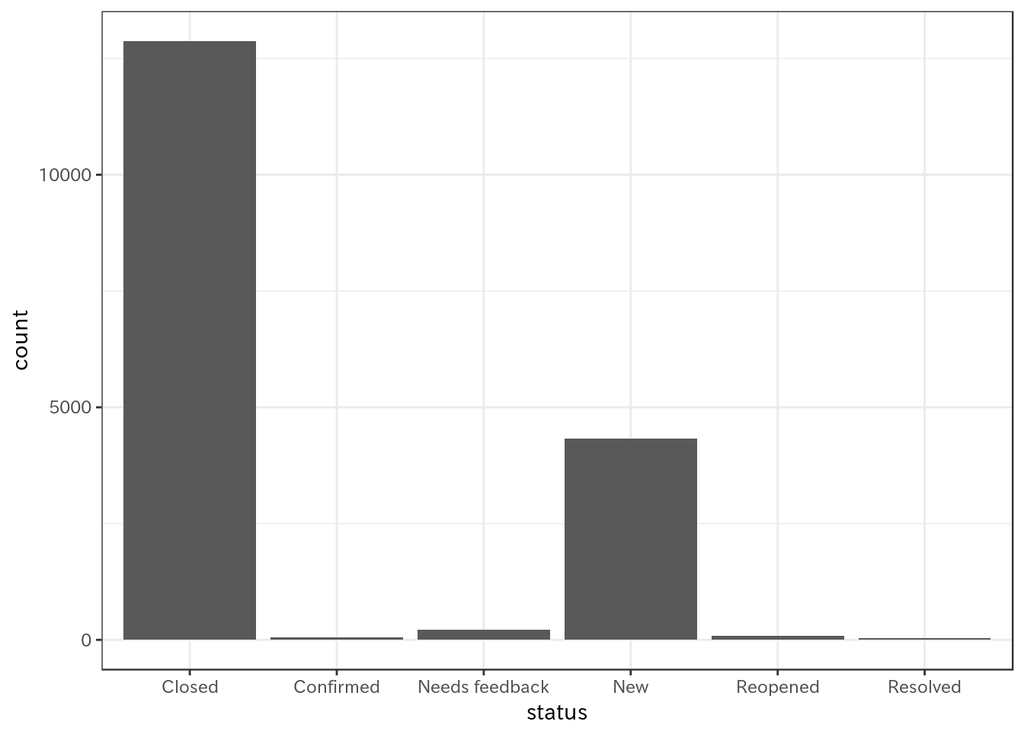

```r
#windowsFonts("MEI"=windowsFont("Meiryo"))
df %>% ggplot(aes(x = status)) +
  geom_bar() + theme_bw(base_family = "HiraKakuProN-W3")
```

## 4.2 円グラフ

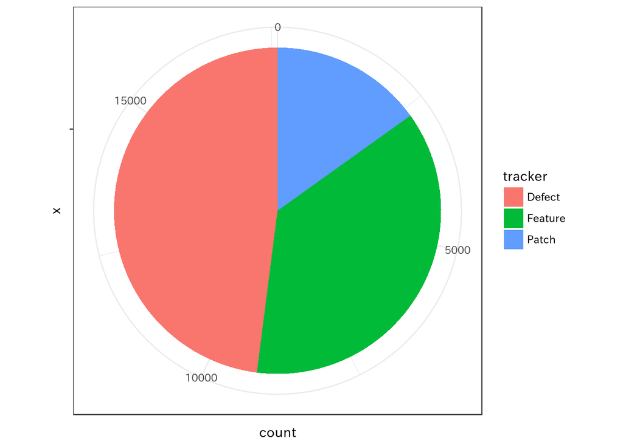

```r
df %>% ggplot(aes(x="", fill=tracker)) +
  geom_bar(width = 1) + coord_polar("y") + theme_bw(base_family = "HiraKakuProN-W3")
```

# 5 Open/Closeチャートを描く

## 5.1 Openチャートを作る

```r
open <- df %>%
  mutate(
    created_on = lubridate::as_date(created_on)
  ) %>%
  dplyr::group_by(created_on) %>%
  dplyr::count() %>%
  dplyr::rename(date = created_on,
                open = n)
open %>% head(100)
```

| date | open |
| --- | --- |
| 2006-06-29 | 1 |
| 2006-07-28 | 3 |
| 2006-08-17 | 2 |
| 2006-11-05 | 1 |
| 2006-11-06 | 1 |
| 2006-12-30 | 1 |
| 2006-12-31 | 1 |
| 2007-01-01 | 2 |
| 2007-01-19 | 1 |
| 2007-01-25 | 1 |

[output cut: 90 more lines]

## 5.2 Closeチャートを作る

```r
close <- df %>%
  dplyr::filter(status=="Closed") %>%
  dplyr::mutate(closed_on = lubridate::as_date(closed_on)) %>%
  dplyr::group_by(closed_on) %>%
  dplyr::count() %>%
  dplyr::rename(
    date = closed_on,
    close = n
  )
close %>% head(100)
```

| date | close |
| --- | --- |
| 2006-06-29 | 1 |
| 2006-07-28 | 3 |
| 2006-08-17 | 2 |
| 2006-11-05 | 1 |
| 2006-11-06 | 1 |
| 2006-12-31 | 1 |
| 2007-01-01 | 2 |
| 2007-01-19 | 1 |
| 2007-01-25 | 1 |
| 2007-01-26 | 1 |

[output cut: 90 more lines]

## 5.3 openとcloseを結合

```r
max_date <- max(open$date, close$date)
min_date <- min(open$date, close$date)
openclose <- data.frame(date=seq(min_date, max_date, by = "day")) %>%
  dplyr::left_join(open, by = "date") %>%
  dplyr::left_join(close, by = "date") %>%
  replace_na(list(open=0, close=0))

openclose
```

| date | open | close |
| --- | --- | --- |
| 2006-06-29 | 1 | 1 |
| 2006-06-30 | 0 | 0 |
| 2006-07-01 | 0 | 0 |
| 2006-07-02 | 0 | 0 |
| 2006-07-03 | 0 | 0 |
| 2006-07-04 | 0 | 0 |
| 2006-07-05 | 0 | 0 |
| 2006-07-06 | 0 | 0 |
| 2006-07-07 | 0 | 0 |
| 2006-07-08 | 0 | 0 |

[output cut: 4482 more lines]

## 5.4 Open/Closeチャートを描く

```r
openclose$cumsum_open <- cumsum(openclose$open)
openclose$cumsum_close <- cumsum(openclose$close)
openclose %>% head(100)
```

|  | date | open | close | cumsum_open | cumsum_close |
| --- | --- | --- | --- | --- | --- |
| 1 | 2006-06-29 | 1 | 1 | 1 | 1 |
| 2 | 2006-06-30 | 0 | 0 | 1 | 1 |
| 3 | 2006-07-01 | 0 | 0 | 1 | 1 |
| 4 | 2006-07-02 | 0 | 0 | 1 | 1 |
| 5 | 2006-07-03 | 0 | 0 | 1 | 1 |
| 6 | 2006-07-04 | 0 | 0 | 1 | 1 |
| 7 | 2006-07-05 | 0 | 0 | 1 | 1 |
| 8 | 2006-07-06 | 0 | 0 | 1 | 1 |
| 9 | 2006-07-07 | 0 | 0 | 1 | 1 |
| 10 | 2006-07-08 | 0 | 0 | 1 | 1 |

[output cut: 90 more lines]

## 5.5 Open/Closeチャートを描く

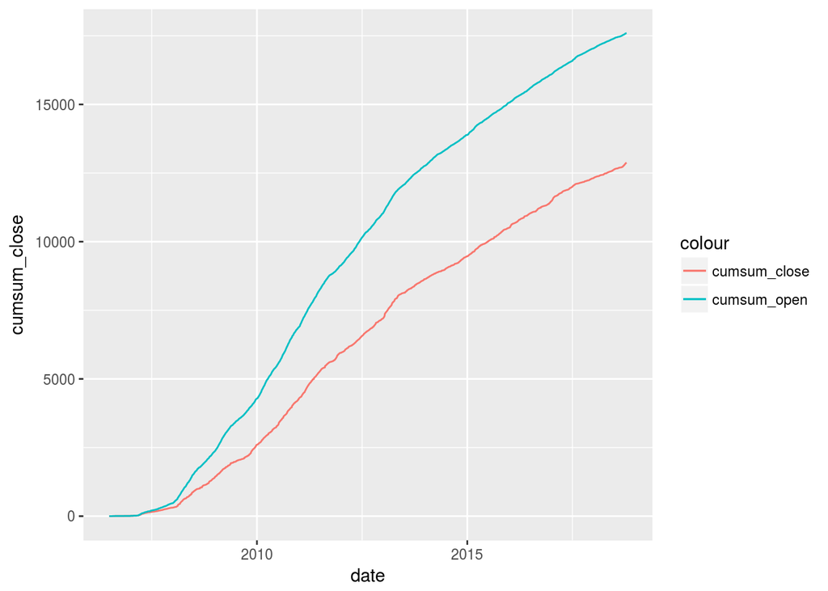

```r
openclose %>%
  ggplot(aes(x = date)) +
  geom_line(aes(y = cumsum_close, color = "cumsum_close")) +
  geom_line(aes(y = cumsum_open, color = "cumsum_open"))
```

# 6 カスタムフィールドの扱い（未完成）

## 6.1 custom_fieldsの中身

```r
tmp_custom_fields
```

```
## [[1]]
## [[1]][[1]]
## [[1]][[1]]$id
## [1] 2
##
## [[1]][[1]]$name
## [1] "Resolution"
##
## [[1]][[1]]$value
## [1] "Invalid"
##
##
## [[1]][[2]]
## [[1]][[2]]$id
## [1] 4
##
## [[1]][[2]]$name
## [1] "Affected version"
##
## [[1]][[2]]$value
## [1] "133"
```

とっても複雑な構造。。。  
要するにこういうこと

```r
list(
  list(
    list(id=2, name="Resolution", value="Invalid"),
    list(id=4, name="Affected version", value=133)
  )
)
```

| フィールド | フィールドの説明 |
| --- | --- |
| id | カスタムフィールドID |
| name | カスタムフィールド名 |
| value | カスタムフィールドの値(※) |

※ プルダウンで選ぶ形式のカスタムフィールドの場合、 valueは各選択肢へのIDになっている。 実際の値を得るためには、バージョンやカスタムフィールドの情報を別途APIを叩いて入手するしかない。

以下が、カスタムフィールドの値取得に必要なAPIだが、 残念ながらredmineRでは取れない。 そのため、REST Client（`RCurl` or `httr`がメジャーらしい）を使って、 直接REST APIを叩くことになる。  
jsonの中身を分析するだけなので、頑張ればできる。

| フィールドの種類 | API | 必要な権限 |
| --- | --- | --- |
| version | [/projects//versions](http://www.redmine.org/projects/redmine/wiki/Rest_Versions) | 普通でOK |
| list | [/custom_fields](http://www.redmine.org/projects/redmine/wiki/Rest_CustomFields) | 管理者権限 |

## 6.2 カスタムフィールドをdata.frameに格納

mutateやpurrr使っても上手くいかなかった。  
そのため、for文でぶん回す。

```r
for(i in 1:nrow(df)){
  if(!is.na(issues[i,"custom_fields"])){
    for(custom_field in issues[i,"custom_fields"][[1]]){
      if(!is.null(custom_field$value)){
        df[i, custom_field$name] <- custom_field$value
      }
    }
  }
}
```

ResolutionとAffected versionが取れた。

```r
df %>%
  dplyr::select("id", "Resolution", "Affected version")
```

| id | Resolution | Affected version |
| --- | --- | --- |
| 29767 | NA | NA |
| 29764 |  | NA |
| 29763 | Invalid | NA |
| 29758 |  | NA |
| 29757 |  | NA |
| 29756 |  | 134 |
| 29753 | Invalid | 133 |
| 29752 |  | NA |
| 29750 |  | NA |
| 29746 |  |  |

[output cut: 9990 more lines]

Affected versionの値はversionのID。 実際にどのバージョンかを知るためには、version取得APIを叩いて、値を検索する。

# 7 効率的なカスタムフィールルドの展開

カスタムフィールドは前述のようにリスト型変数がネストしている構造（入れ子構造）で、処理が厄介です。ネストを効率的に反復的に処理するには`purrr`パッケージを用います。

## 7.1 カスタムフィールドの確認

カスタムフィールドの中身を再確認しておきます。（このような場合は`knitr::kable`関数を用いると分かりやすい）

```r
issues %>%
  head() %>%
  dplyr::select(id, custom_fields) %>%
  knitr::kable()
```

| id | custom_fields |
| --- | --- |
| 29767 | NA |
| 29764 | list(list(id = 2, name = “Resolution”, value = “”)) |
| 29763 | list(list(id = 2, name = “Resolution”, value = “Invalid”)) |
| 29758 | list(list(id = 2, name = “Resolution”, value = “”)) |
| 29757 | list(list(id = 2, name = “Resolution”, value = “”)) |
| 29756 | list(list(id = 2, name = “Resolution”, value = “”), list(id = 4, name = “Affected version”, value = “134”)) |

このようにカスタムフィールドはチケットによりフィールドがあったり、なかったり、数が異なっていたりしています。

## 7.2 カスタムフィールドの展開

カスタムフィールドを処理するには、最初にネスト構造を展開して単一のリスト型変数にすることから始めます。リスト構造を展開するには`tidyr::unnest`関数を用います。

```r
issues %>%
  head() %>%
  dplyr::select(id, custom_fields) %>% as.data.frame() %>%
  tidyr::unnest() %>% knitr::kable()
```

| id | custom_fields |
| --- | --- |
| 29767 | NULL |
| 29764 | list(id = 2, name = “Resolution”, value = “”) |
| 29763 | list(id = 2, name = “Resolution”, value = “Invalid”) |
| 29758 | list(id = 2, name = “Resolution”, value = “”) |
| 29757 | list(id = 2, name = “Resolution”, value = “”) |
| 29756 | list(id = 2, name = “Resolution”, value = “”) |
| 29756 | list(id = 4, name = “Affected version”, value = “134”) |

`tidyr::unnest`関数を用いると複数のリスト型変数がネストされている部分に対しては複数行に展開してくれますので、識別子（この場合はチケット番号である`id`）と共に適用する必要があります。また、`NA`の場合には`NULL`になりますので、この次の展開のために`NULL`データを削除しておきます。

```r
issues %>%
  head() %>%
  dplyr::select(id, custom_fields) %>% as.data.frame() %>%
  tidyr::unnest() %>%
  tidyr::drop_na() %>% knitr::kable()
```

|  | id | custom_fields |
| --- | --- | --- |
| 2 | 29764 | list(id = 2, name = “Resolution”, value = “”) |
| 3 | 29763 | list(id = 2, name = “Resolution”, value = “Invalid”) |
| 4 | 29758 | list(id = 2, name = “Resolution”, value = “”) |
| 5 | 29757 | list(id = 2, name = “Resolution”, value = “”) |
| 6 | 29756 | list(id = 2, name = “Resolution”, value = “”) |
| 7 | 29756 | list(id = 4, name = “Affected version”, value = “134”) |

以降の処理は、前出の`purrr::map`関数群を適用することが出来るようになります。

```r
map_if_chr <- function(.x, .f) {
  purrr::map_if(.x, !is.na(.x), .f) %>%
    purrr::map_chr(1L) %>%
    return()
}

issues %>%
  head(100) %>%
  dplyr::select(id, custom_fields) %>% as.data.frame() %>%
  tidyr::unnest() %>%
  tidyr::drop_na() %>%
  dplyr::mutate(name = map_if_chr(custom_fields, 'name'),
                value = map_if_chr(custom_fields, 'value')) %>%
  dplyr::select(-custom_fields) %>%
  tidyr::spread(key = name, value = value) %>%
  dplyr::left_join(issues, ., by = "id") %>%
  dplyr::select(id, 'Affected version', 'Resolution') %>%
  dplyr::arrange(dplyr::desc(id))
```

| id | Affected version | Resolution |
| --- | --- | --- |
| 29767 | NA | NA |
| 29764 | NA |  |
| 29763 | NA | Invalid |
| 29758 | NA |  |
| 29757 | NA |  |
| 29756 | 134 |  |
| 29753 | 133 | Invalid |
| 29752 | NA |  |
| 29750 | NA |  |
| 29746 |  |  |

[output cut: 9990 more lines]

## 7.3 イレギュラー処理

カスタムフィールドは上記のように展開できますが、実際には以下のように`Affected version`に`value`が存在しないというようなイレギュラーなデータが存在しています。

```r
issues %>%
  dplyr::filter(id <= 16455 & id >= 16446) %>%
  dplyr::select(id, custom_fields) %>%
  tidyr::unnest() %>% knitr::kable()
```

| id | custom_fields |
| --- | --- |
| 16453 | NULL |
| 16451 | list(id = 2, name = “Resolution”, value = “Invalid”) |
| 16451 | list(id = 4, name = “Affected version”) |
| 16450 | list(id = 2, name = “Resolution”, value = “”) |
| 16449 | list(id = 2, name = “Resolution”, value = “”) |
| 16449 | list(id = 4, name = “Affected version”, value = “75”) |
| 16447 | list(id = 2, name = “Resolution”, value = “Invalid”) |
| 16447 | list(id = 4, name = “Affected version”) |
| 16446 | NULL |

このようなイレギュラーデータに対して`purrr::map`関数群を適用するとSTOPエラーを起こしてしまい処理が完了できません。

```r
issues %>%
  dplyr::filter(id <= 16455 & id >= 16446) %>%
  dplyr::select(id, custom_fields) %>%
  tidyr::unnest() %>%
  dplyr::mutate(name = map_if_chr(custom_fields, 'name'),
                value = map_if_chr(custom_fields, 'value'))
```

```
## Error in mutate_impl(.data, dots): Evaluation error: Result 1 is not a length 1 atomic vector.
```

そこで、このようなイレギュラーデータを処理するには、一度、リスト型変数をデータフレーム型変数に展開しておく必要があります。  
### イレギュラーデータの展開処理 イレギュラーデータを再度確認しておきます。

```r
sample_issues <- issues %>%
  dplyr::filter(id <= 16455 & id >= 16446) %>%
  dplyr::select(id, custom_fields) %>%
  tidyr::unnest() %>%
  tidyr::drop_na() %>%
  dplyr::rename(issue_id = id)

sample_issues %>% knitr::kable()
```

|  | issue_id | custom_fields |
| --- | --- | --- |
| 2 | 16451 | list(id = 2, name = “Resolution”, value = “Invalid”) |
| 3 | 16451 | list(id = 4, name = “Affected version”) |
| 4 | 16450 | list(id = 2, name = “Resolution”, value = “”) |
| 5 | 16449 | list(id = 2, name = “Resolution”, value = “”) |
| 6 | 16449 | list(id = 4, name = “Affected version”, value = “75”) |
| 7 | 16447 | list(id = 2, name = “Resolution”, value = “Invalid”) |
| 8 | 16447 | list(id = 4, name = “Affected version”) |

このようにリスト型変数内にはチケット番号を識別するための識別子を持っていません。最初の`id`は、カスタムフィールドの識別子です。そこで、リスト型変数内にチケット番号の識別子（ここでは`issue_id`と名前を変えてあります）を入れ込みます。リスト型変数は`c`関数を用いて単純に結合するだけでリスト内の変数を追加できます。

```r
c(issue_id = sample_issues$issue_id[1], sample_issues$custom_fields[[1]])
```

```
## $issue_id
## [1] 16451
##
## $id
## [1] 2
##
## $name
## [1] "Resolution"
##
## $value
## [1] "Invalid"
```

この結合処理を各データに対して反復して適用しますので、反復処理を得意とする`purrr`パッケージを利用します。

```r
purrr::map2_df(sample_issues$issue_id, sample_issues$custom_fields,
            .f = function(.x, .y) {c(issue_id = .x, .y)})
```

| issue_id | id | name | value |
| --- | --- | --- | --- |
| 16451 | 2 | Resolution | Invalid |
| 16451 | 4 | Affected version | NA |
| 16450 | 2 | Resolution |  |
| 16449 | 2 | Resolution |  |
| 16449 | 4 | Affected version | 75 |
| 16447 | 2 | Resolution | Invalid |
| 16447 | 4 | Affected version | NA |

`purrr::map2`関数群は、`purrr::map`関数群の拡張てきな関数群であり、二つの引数（`.x`, `.y`）に対して`.f`で指定した処理（関数や演算子など）を適用する関数です。ここでは出力を見やすくするためにデータフレーム型の出力にしていますが、実際の処理ではリスト型に出力するタイプの関数を用います。

```r
purrr::map2_df(sample_issues$issue_id, sample_issues$custom_fields,
               .f = function(.x, .y) {c(issue_id = .x, .y)}) %>%
  as.data.frame()
```

| issue_id | id | name | value |
| --- | --- | --- | --- |
| 16451 | 2 | Resolution | Invalid |
| 16451 | 4 | Affected version | NA |
| 16450 | 2 | Resolution |  |
| 16449 | 2 | Resolution |  |
| 16449 | 4 | Affected version | 75 |
| 16447 | 2 | Resolution | Invalid |
| 16447 | 4 | Affected version | NA |

これでチケット番号（Redmine上では`id`）に紐付いたカスタムフィールド情報を取得することができました。あとは、以前に学んだ`tidyr::spread`関数を用いてカスタムフィールド（`name`）が変数になるように展開します。

```r
purrr::map2_df(sample_issues$issue_id, sample_issues$custom_fields,
               .f = function(.x, .y) {c(issue_id = .x, .y)}) %>%
  dplyr::select(-id) %>%
  tidyr::spread(key = name, value = value) %>%
  dplyr::rename(id = issue_id)
```

| id | Affected version | Resolution |
| --- | --- | --- |
| 16447 | NA | Invalid |
| 16449 | 75 |  |
| 16450 | NA |  |
| 16451 | NA | Invalid |

## 7.4 カスタムフィールドの結合

カスタムフィールドが展開できましたので、あとは、チケットデータに対して識別子であるチケット番号（`id`）を元に結合処理を行います「。

```r
cf_list <- issues %>%
  dplyr::select(id, custom_fields) %>%
  tidyr::unnest() %>%
  tidyr::drop_na()

df_cf <- purrr::map2_df(cf_list$id, cf_list$custom_fields,
                        .f = function(.x, .y) {c(iid = .x, .y)}) %>%
  dplyr::select(-id) %>%
  tidyr::spread(key = name, value = value) %>%
  dplyr::rename(id = iid) %>%
  dplyr::arrange(dplyr::desc(id))

issues %>%
  dplyr::select(id, subject) %>%
  dplyr::left_join(df_cf, by = "id")
```

| id | subject | Affected version | Resolution |
| --- | --- | --- | --- |
| 29767 | Traditional Chinese translation (to r17594) | NA | NA |
| 29764 | new filed 'Related Issues Notes' for pair of related issues | NA |  |
| 29763 | Better linux distribution to install redmine | NA | Invalid |
| 29758 | Introduce optional pay per feature model of Redmine development | NA |  |
| 29757 | Make "First name" and "Last name" optional (not required) in user's settings | NA |  |
| 29756 | \\f and \\v characters in Textile markup may cause RegexpError exception | 134 |  |
| 29753 | View estimated hours doen't work for root issue | 133 | Invalid |
| 29752 | Render Textile and Markdown attachments as HTML on the preview page | NA |  |
| 29750 | Per project intergated IDE module with live collaboration support | NA |  |
| 29746 | Unexpected results with enumeration formatting in Textile |  |  |

[output cut: 9990 more lines]

ここでは表示の都合上、チケット番号、タイトル、カスタムフィールドのみに絞ってありますが、結合処理により全てのリスト型変数に対する展開処理が終わったことになります。以降は各変数を用いた分析や可視化を行ってください。